# Influência da quantidade de colaboradores no desenvolvimento de software

Veruska Santos

4 de abril de 2018

No processo de desenvolvimento de um software é muito comum que as equipes possuam 2 ou mais colaboradores, para diminuir o tempo de produção e otimizar a troca de experiências. Com o objetivo de identificar possíveis relações entre os colaboradores e o processo de desenvolvimento de software, este relatório visa analisar, utilizando a linguagem R, um conjunto de projetos de desenvolvimento de software, já pré-processadas pelo prof. Nazareno

É também comum no desenvolvimento de software utilizar sistemas de controle de versão (SCV), para que as equipes tenham acesso ao mesmo código atualizado. Assim, cada colaborador, ao fazer modificações no código, envia-as para a equipe através do envio de um commit para o SCV. Alguns SCV são integrados com outros sistemas que, a cada, **commit**, ou seja, modificação no código do SCV, compila esse código e executa os seus testes, para verificar se a integridade do mesmo está mantida. A este verificação dá-se o nome de **build**.

## Pré-processamento dos dados

Importando biblioteca do R a ser usada para ler os dados e manipulá-los.

```r
library(tidyverse)
```

Carregando os dados, já processados, que serão analisados.

```r
projetos = read_csv(here::here("data/projetos.csv"))
```

Abaixo, descartamos projetos que não queremos analisar, por exemplo, aqueles cuja linguagem dominante é Javascript, somando 4.

```r
projetos = projetos %>%
    filter(lang != "javascript")
```

Para estudar algumas relações entre variáveis, criamos 4 Questões de Pesquisa (QP) para respondermos através de análises gráficas.

## QP1: Há relação entre a quantidade de colaboradores dos projetos e o número total de commits e o total de builds?

Em uma equipe de desenvolvimento, o ideal e esperado é que todos os colaboradores contribuam de forma similar com o projeto. Se uma equipe possui mais colaboradores há indícios de que o projeto seja mais complexo. Assim, espera-se que, quanto mais colaboradores de um projeto, maior seja a atividade do mesmo. Atividade aqui estamos representando como o total de commits e o total de builds.

O gráfico abaixo exibe a relação entre a quantidade de colaboradores de uma equipe e o total de commits realizado pelos mesmos.

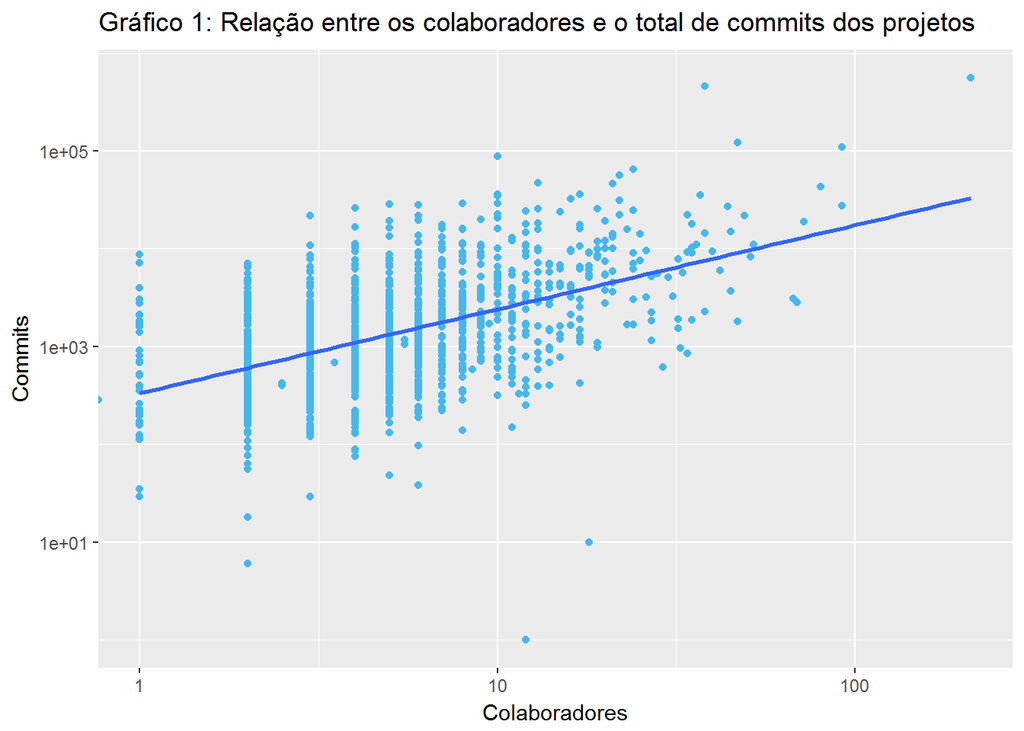

```r
projetos %>%
    ggplot(aes(x = team, y = num_commits)) +
    geom_point(color = "#44b8ee") +
    geom_smooth(method = "lm", se = F) +
    scale_x_log10() +
    scale_y_log10() +
    ggtitle("Gráfico 1: Relação entre os colaboradores e o total de commits dos projetos") +
    xlab("Colaboradores") +
    ylab("Commits")
```

Os dados mostram que, há uma relação crescente entre as equipes com poucos colaboradores e o número total de commits realizados. Assim, quanto maior uma equipe de desenvolvimento maior tende a ser a atividade do projeto. Para as equipes acima de 10 colaboradores não há relação explícita entre o tamanho da equipe e o total de commits.

As mesmas conclusões se aplicam para a relação entre o tamanho da equipe de desenvolvimento e o total de builds do projeto, mostradas no Gráfico 2 abaixo.

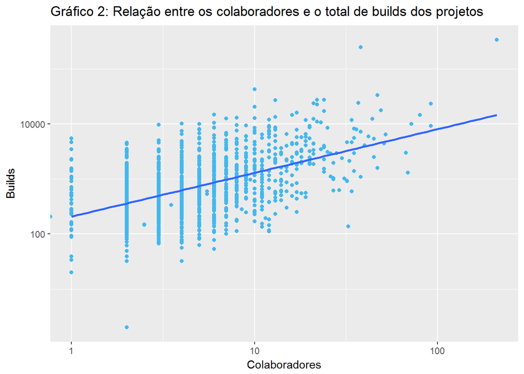

```r
projetos %>%
    ggplot(aes(x = team, y = total_builds)) +
    geom_point(color = "#44b8ee") +
    geom_smooth(method = "lm", se = F) +
    scale_x_log10() +
    scale_y_log10() +
    ggtitle("Gráfico 2: Relação entre os colaboradores e o total de builds dos projetos") +
    xlab("Colaboradores") +
    ylab("Builds")
```

Desse modo, para a QP1 concluímos que há uma relação crescente moderada entre a quantidadade de colaboradores e o total de commits e de builds do projeto.

## QP2: Projetos longos, com mais de 2 anos de atividade, são projetos grandes?

Projetos de desenvolvimento de software, em geral, são desenvolvidos em poucos meses. Aqueles que levam mais tempo são considerados como mais complexos e, possivelmente, maiores. Para confirmar tal hipótese, geramos o gráfico abaixo que exibe o período de atividade de cada projeto e o seu tamanho do código (total de linhas).

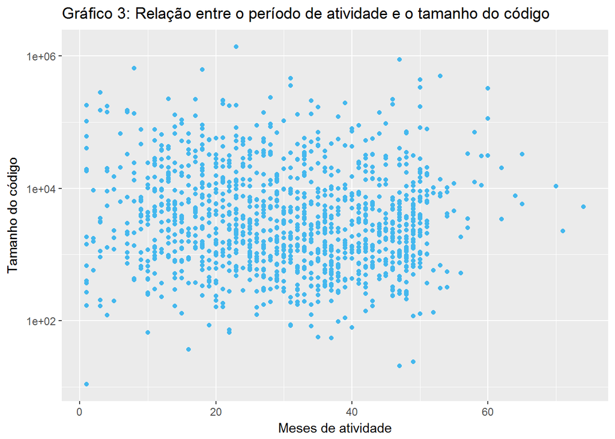

```r
projetos %>%
    ggplot(aes(x = activity_period, y = sloc_end)) +
    geom_point(color = "#44b8ee") +
    scale_y_log10() +
    ggtitle("Gráfico 3: Relação entre o período de atividade e o tamanho do código") +
    xlab("Meses de atividade") +
    ylab("Tamanho do código")
```

Analisando o Gráfico 3 percebemos que não há qualquer relação entre o período de atividade de um projeto e o tamanho do mesmo, pois os pontos, que representam os projetos, estão espalhados por todo o gráfico. Assim, respondendo a QP2, não podemos afirmar que um projeto longo é necessariamente grande, porque, nos dados, há diversos projetos pequenos com mais de 2 anos de atividade, bem como há projetos grandes com pouco tempo de atividade.

## QP3: Há relação entre o tamanho do código e a quantidade de colaboradores?

Diante da análise sobre a QP1, percebemos que existe uma relação entre a quantidade de colaboradores e o aumento na atividade do projeto. Assim, decidimos analisar se também há uma relação crescente entre a quantidade de colaboradores e o tamanho do código.

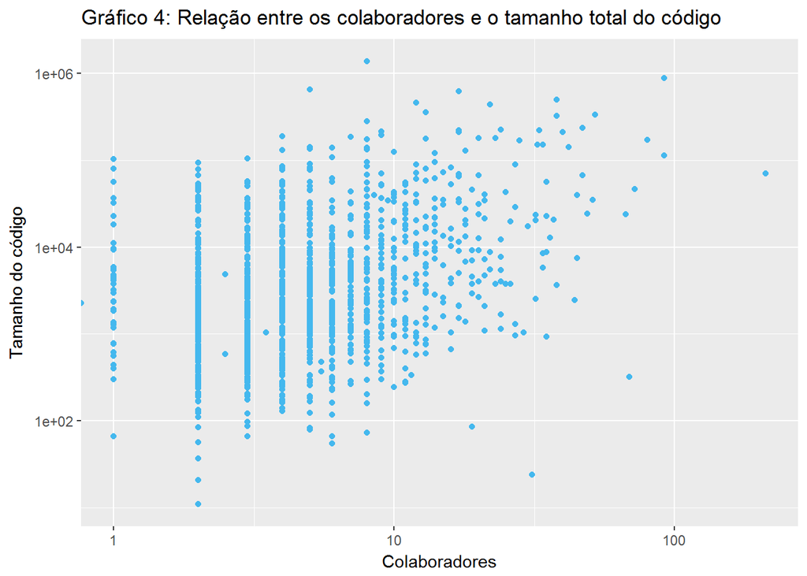

```r
projetos %>%
    ggplot(aes(x = team, y = sloc_end)) +
    scale_x_log10() +
    scale_y_log10() +
    geom_point(color = "#44b8ee") +
    ggtitle("Gráfico 4: Relação entre os colaboradores e o tamanho total do código") +
    xlab("Colaboradores") +
    ylab("Tamanho do código")
```

O Gráfico 4 nos mostra que existe uma fraca relação crescente entre as variáveis analisadas, ou seja, quanto maior a quantidade de colaboradores em um projeto maior tende a ser, geralmente, o tamanho do código.

## QP4: Há relação entre o tamanho da equipe e a proporção de builds de sucesso?

Após a análise da QP1, também surgiu a hipótese de que pode haver relação entre o tamanho da equipe e a proporção de builds de sucesso, já que, em geral, as equipes maiores trabalham mais. Assim, geramos o gráfico abaixo.

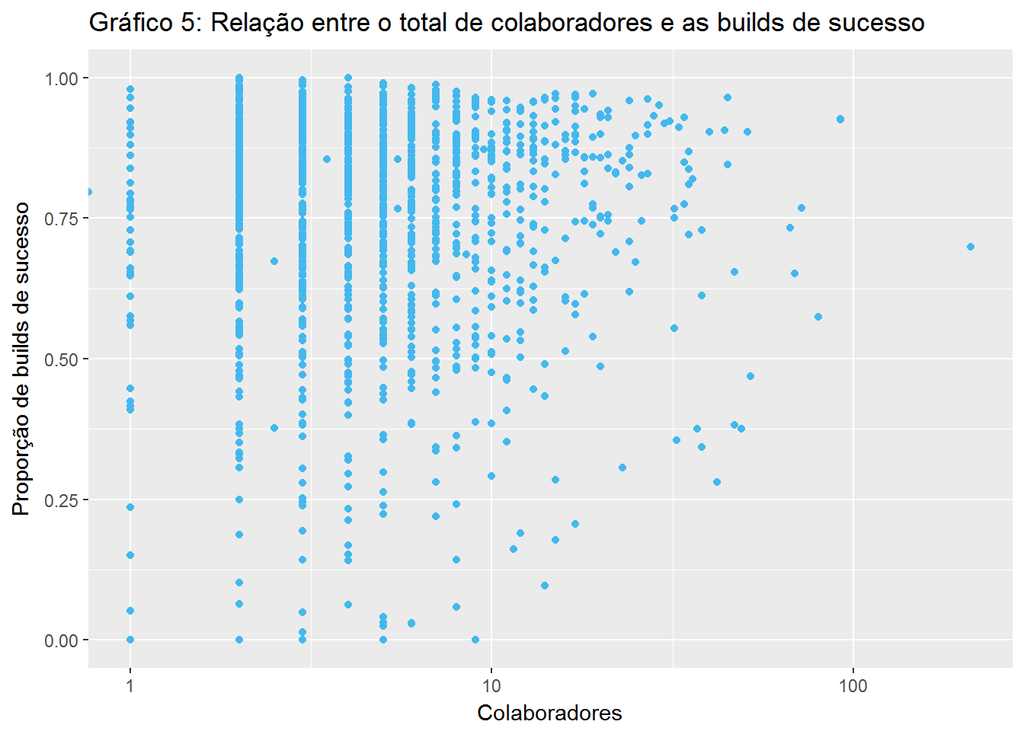

```r
projetos %>%
    ggplot(aes(x= team, y=build_success_prop)) +
    scale_x_log10() +
    geom_point(color = "#44b8ee") +
    ggtitle("Gráfico 5: Relação entre o total de colaboradores e as builds de sucesso") +
    xlab("Colaboradores") +
    ylab("Proporção de builds de sucesso")
```

O gráfico 5 nos mostra que não existe relação entre a quantidade de colaboradores e a proporção de builds de sucesso. Todos os projetos analisados possuem valores variados de proporção de build, independente da quantidade de colaboradores.

## Confirmando os resultados

As análises acima nos possibilitaram ver os dados graficamente e identificar possíveis padrões entre as variáveis. Quando há relação entre as variáveis é fácil identificar tal padrão, como é o exemplo da QP1, porém, quando as variáveis não são relacionadas é mais difícil inferir alguma conclusão.

Para confirmar os resultados, analisamos estatisticamente a relação entre as variáveis através dos coeficientes de correlação (Pearson, Spearman e Kendal) e exibimos os valores abaixo. O valor dos coefientes estão entre [-1,1], o que significa que quanto mais perto dos extremos maior é a relação entre as variáveis, e quanto mais perto de zero, menor ou insignificante é a relação. O sinal indica a direção do relacionamento: decrescente (-) ou crescente (+).

- O coeficiente de Pearson mede o grau do relacionamento entre variáveis linearmente relacionadas.
- O coeficiente de Spearman é um teste não paramétrico que é usado para medir o grau de associação entre duas variáveis, sem considerar a distribuição dos dados.
- O coeficiente de Kendal é um teste não paramétrico que mede a força de dependência entre duas variáveis.

Para a QP1, Gráfico 1:

```r
projetos %>%
  summarise(pearson = cor(team, num_commits, method = "pearson"),
            spearman = cor(team, num_commits, method = "spearman"),
            kendall = cor(team, num_commits, method = "kendall"))
```

```
## # A tibble: 1 x 3
##   pearson spearman kendall
##     <dbl>    <dbl>   <dbl>
## 1   0.596    0.486   0.353
```

Para a QP1, Gráfico 2:

```r
projetos %>%
  summarise(pearson = cor(team, total_builds, method = "pearson"),
            spearman = cor(team, total_builds, method = "spearman"),
            kendall = cor(team, total_builds, method = "kendall"))
```

```
## # A tibble: 1 x 3
##   pearson spearman kendall
##     <dbl>    <dbl>   <dbl>
## 1   0.583    0.459   0.331
```

Para a QP2, Gráfico 3:

```r
projetos %>%
  summarise(pearson = cor(activity_period, sloc_end, method = "pearson"),
            spearman = cor(activity_period, sloc_end, method = "spearman"),
            kendall = cor(activity_period, sloc_end, method = "kendall"))
```

```
## # A tibble: 1 x 3
##   pearson spearman kendall
##     <dbl>    <dbl>   <dbl>
## 1 -0.0336  -0.0964 -0.0640
```

Para a QP3, Gráfico 4:

```r
projetos %>%
  summarise(pearson = cor(team, sloc_end, method = "pearson"),
            spearman = cor(team, sloc_end, method = "spearman"),
            kendall = cor(team, sloc_end, method = "kendall"))
```

```
## # A tibble: 1 x 3
##   pearson spearman kendall
##     <dbl>    <dbl>   <dbl>
## 1   0.284    0.321   0.228
```

Para a QP4, Gráfico 5:

```r
projetos %>%
  summarise(pearson = cor(team, build_success_prop, method = "pearson"),
            spearman = cor(team, build_success_prop, method = "spearman"),
            kendall = cor(team, build_success_prop, method = "kendall"))
```

```
## # A tibble: 1 x 3
##   pearson spearman kendall
##     <dbl>    <dbl>   <dbl>
## 1  0.0249   0.0614  0.0430
```

Assim, concluímos que, das variáveis analisadas, somente a quantidade de colaboradores influencia na atividade do projeto, ou seja, em um projeto de desenvolvimento de software, o tamanho da equipe influencia nas atividades do projeto.

**Links úteis:**

- Dados utilizados nesta análise: https://travistorrent.testroots.org
- Coeficientes de correlação: https://www.statisticssolutions.com/correlation-pearson-kendall-spearman/